# Logisitic Regression with Categorical Predictors

## Logistic Model

```r
library(dplyr)
library(ggplot2)
library(pROC)
theme_set(theme_bw(base_size = 16))

crab <- read.table("http://www.stat.ufl.edu/~aa/cat/data/Crabs.dat",
                   header = TRUE)

## Make vector of factor
crab$colorf <- factor(crab$color)

fit <- glm(y ~ width, family = binomial, data = crab)
summary(fit)
```

```
##
## Call:
## glm(formula = y ~ width, family = binomial, data = crab)
##
## Coefficients:
##             Estimate Std. Error z value  Pr(>|z|)
## (Intercept)  -12.351      2.629   -4.70 0.0000026 ***
## width          0.497      0.102    4.89 0.0000010 ***
## ---
## Signif. codes:  0 '***' 0.001 '**' 0.01 '*' 0.05 '.' 0.1 ' ' 1
##
## (Dispersion parameter for binomial family taken to be 1)
##
##     Null deviance: 225.76  on 172  degrees of freedom
## Residual deviance: 194.45  on 171  degrees of freedom
## AIC: 198.5
##
## Number of Fisher Scoring iterations: 4
```

```r
exp(coef(fit))
```

```
##  (Intercept)        width
## 0.0000043262 1.6441615976
```

## Confusion Matrix / Classification Table

```r
## Make vector of factor
crab$colorf <- factor(crab$color)

fit <- glm(y ~ width + colorf, family = binomial, data = crab)

## Sample proportion crabs with sat
(prop <- sum(crab$y) / nrow(crab))
```

```
## [1] 0.64162
```

```r
predval <- as.numeric(fitted(fit) > prop)

xtabs(~ crab$y + predval)
```

```
##       predval
## crab$y  0  1
##      0 43 19
##      1 36 75
```

```r
## Try again with pi0 = 50
predval50 <- as.numeric(fitted(fit) > 0.5)
xtabs(~ crab$y + predval50)
```

```
##       predval50
## crab$y  0  1
##      0 31 31
##      1 15 96
```

In most cases, we could also just as well use `table`

```r
table(crab$y, predval50)
```

```
##    predval50
##      0  1
##   0 31 31
##   1 15 96
```

# ROC

```r
rocplot <- roc(y ~ fitted(fit), data = crab)

with(rocplot, cbind(thresholds, specificities, sensitivities)) %>% head()
```

```
##      thresholds specificities sensitivities
## [1,]       -Inf      0.000000       1.00000
## [2,]   0.076877      0.016129       1.00000
## [3,]   0.123589      0.016129       0.99099
## [4,]   0.149141      0.032258       0.99099
## [5,]   0.158344      0.048387       0.99099
## [6,]   0.188201      0.080645       0.99099
```

```r
with(rocplot, cbind(thresholds, specificities, sensitivities)) %>% tail()
```

```
##        thresholds specificities sensitivities
## [104,]    0.94295             1      0.045045
## [105,]    0.94844             1      0.036036
## [106,]    0.96101             1      0.027027
## [107,]    0.97254             1      0.018018
## [108,]    0.98061             1      0.009009
## [109,]        Inf             1      0.000000
```

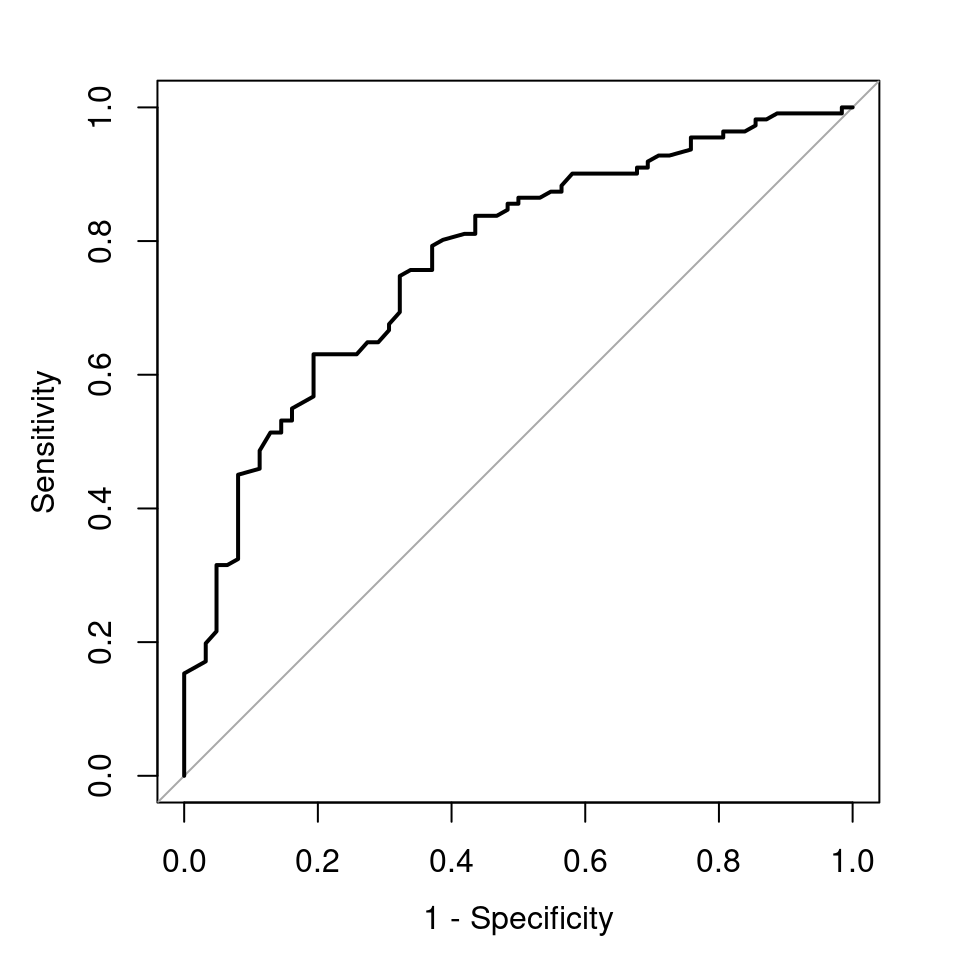

```r
plot.roc(rocplot, legacy.axes = TRUE)
```

```r
auc(rocplot)
```

```
## Area under the curve: 0.771
```

We can also use the `plotROC` package which creates slightly nicer plots with estimates for $\pi_0$ annotated on the chart. Note the aesthetics `m` for $\hat{y}$ and `d` for $y$.

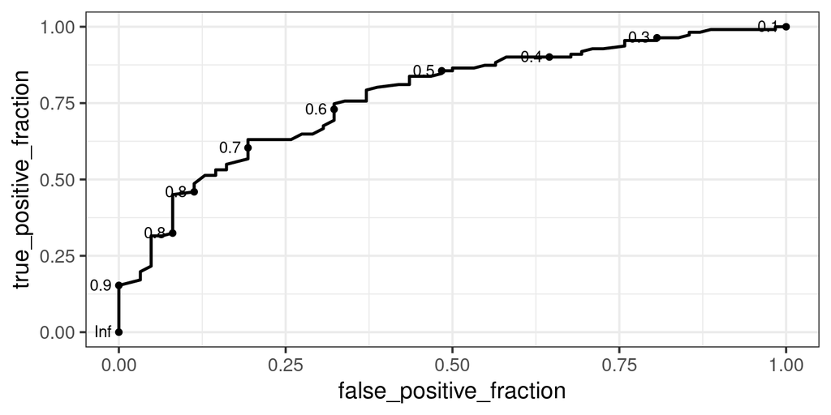

```r
library(plotROC)

## Put fitted values back in data.frame
crab$fitval <- fitted(fit)

ggplot(crab) + geom_roc(aes(d = y, m = fitval))
```

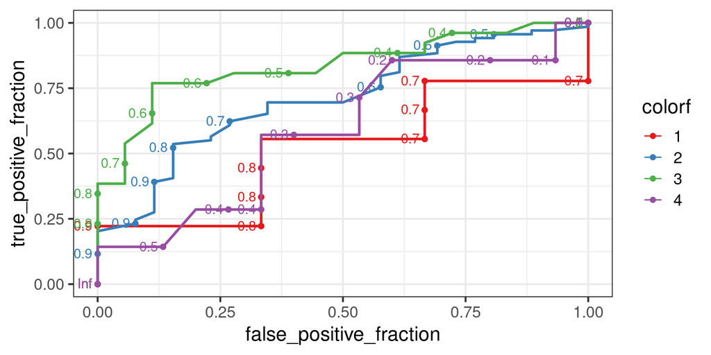

```r
ggplot(crab, aes(color = colorf)) + geom_roc(aes(d = y, m = fitval)) +
  scale_color_brewer(palette = "Set1")
```

This package also has its own suite of additional functions. To use them, we must assign the ggplot to a new variable

```r
m1 <- ggplot(crab) + geom_roc(aes(d = y, m = fitval))
m2 <- ggplot(crab, aes(color = colorf)) + geom_roc(aes(d = y, m = fitval))

calc_auc(m1)
```

```
##   PANEL group     AUC
## 1     1    -1 0.77136
```

```r
calc_auc(m2) # AUC for each level of factor
```

```
##   PANEL group colorf     AUC
## 1     1     1      1 0.51852
## 2     1     2      2 0.71014
## 3     1     3      3 0.83654
## 4     1     4      4 0.59048
```

An inconvenient note: when using the `plotROC` package, there is a bug in `calc_auc` if you specify any aesthetics in `geom_roc` except for `d` and `m`. For example, this code would not work because `colorf` is specified in `geom_roc` instead of `ggplot()`:

```r
m2 <- ggplot(crab) + geom_roc(aes(d = y, m = fitval, color = colorf))
calc_auc(m2)
```

```
## Error in `rlang::quo_get_expr()`:
## ! `quo` must be a quosure
```

## Exercises

The code below loads game data from the Golden State Warriors’ 2015-2016 season. The outcome of the game will be our response.

```r
gsw <- read.csv("https://remiller1450.github.io/data/GSWarriors.csv")
gsw$win_binary <- ifelse(gsw$Win == "W", 1, 0) # response var
```

**Part A** Fit a logistic regression model using only `FG3A` as a predictor. This variable represents the number of three-point shots *attempted* in a game. Interpret the fitted coefficient

**Part B** Fit a logistic model again, this time using both `FG3A` (attempts) *and* `FG3` where `FG3` represents the number of attempts *actually made*. Examine the coefficients and explain why the sign of `FG3A` has changed. (Recall: coefficients are interpreted in isolation, assuming *all other values are held constant*)

**Part C** Create ROC curves associated with each of the models created.